# Cyberbullying Detection

#### This is a cyberbullying detection website that detects if there is bullying and the type of bullying in a comment. Because the data is not clean, there are many pre processing steps that are needed in order to use it to train the model.

# Here is the link to the website ("https://hezron-like-bullying.streamlit.app/")

```python
import pandas as pd
import seaborn as sns
import matplotlib.pyplot as plt
import numpy as np
from sklearn.preprocessing import OneHotEncoder, StandardScaler, MinMaxScaler
from sklearn.model_selection import GridSearchCV, train_test_split, KFold, cross_val_score
from sklearn.linear_model import LinearRegression
from sklearn.metrics import r2_score, mean_squared_error, accuracy_score, mean_absolute_error, mean_squared_error
from sklearn.ensemble import GradientBoostingRegressor
from sklearn.neural_network import MLPRegressor
from sklearn.svm import SVR
from sklearn.neighbors import KNeighborsRegressor
from sklearn.cross_decomposition import PLSRegression
from sklearn.tree import DecisionTreeRegressor
import missingno as msno
from sklearn.utils import shuffle
# from category_encoders import TargetEncoder, OneHotEncoder
import warnings
import re
```

# Data Selection

#### the dataset is from kaggle (https://www.kaggle.com/datasets/andrewmvd/cyberbullying-classification), this dataset was chosen because it has a variety of bullying comments compared to other datasets. It also has a ideal number of comments in the dataset. The dataset is also suitable for NLP tasks because it requires a lot of preprocessing steps in order to train on it.

```python
df = pd.read_csv("C://Users/60102/Desktop/NLP/cyberbullying_tweets.csv", encoding="iso-8859-1", low_memory=False)
pd.set_option('display.max_colwidth', 100)
```

[output not shown]

[output cut: 38 more lines]

[output not shown]

```python
df.head()
```

|  | tweet_text | cyberbullying_type |
| --- | --- | --- |
| 0 | In other words #katandandre, your food was crapilicious! #mkr | not_cyberbullying |
| 1 | Why is #aussietv so white? #MKR #theblock #ImACelebrityAU #today #sunrise #studio10 #Neighbours ... | not_cyberbullying |
| 2 | @XochitlSuckkks a classy whore? Or more red velvet cupcakes? | not_cyberbullying |
| 3 | @Jason_Gio meh. :P thanks for the heads up, but not too concerned about another angry dude on t... | not_cyberbullying |
| 4 | @RudhoeEnglish This is an ISIS account pretending to be a Kurdish account. Like Islam, it is al... | not_cyberbullying |

# 1.0 Data Pre-processing

```python
df['cyberbullying_type'].replace(['not_cyberbullying', 'gender', 'religion', 'age', 'ethnicity', 'other_cyberbullying'],
                        [0, 1, 2, 3, 4, 5], inplace=True)
```

```python
df.head()
```

|  | tweet_text | cyberbullying_type |
| --- | --- | --- |
| 0 | In other words #katandandre, your food was crapilicious! #mkr | 0 |
| 1 | Why is #aussietv so white? #MKR #theblock #ImACelebrityAU #today #sunrise #studio10 #Neighbours ... | 0 |
| 2 | @XochitlSuckkks a classy whore? Or more red velvet cupcakes? | 0 |
| 3 | @Jason_Gio meh. :P thanks for the heads up, but not too concerned about another angry dude on t... | 0 |
| 4 | @RudhoeEnglish This is an ISIS account pretending to be a Kurdish account. Like Islam, it is al... | 0 |

## 1.1 Check for Null Values

```python
df.isnull().sum()
```

```
tweet_text            0
cyberbullying_type    0
dtype: int64
```

## 1.2 Plot a graph to see the count of tweet for each cyberbullying_type

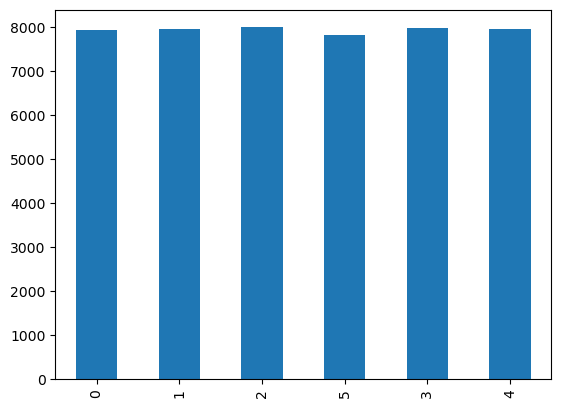

```python
df.cyberbullying_type.value_counts()[df.cyberbullying_type.unique()].plot(kind='bar')
```

## 1.3 Check for duplicate values

```python
df['tweet_text'].duplicated().sum()
```

```
1675
```

```python
df.info()
```

```
<class 'pandas.core.frame.DataFrame'>
RangeIndex: 47692 entries, 0 to 47691
Data columns (total 2 columns):
 #   Column              Non-Null Count  Dtype
---  ------              --------------  -----
 0   tweet_text          47692 non-null  object
 1   cyberbullying_type  47692 non-null  int64
dtypes: int64(1), object(1)
memory usage: 745.3+ KB
```

```python
df.drop_duplicates("tweet_text", inplace=True)
```

```python
df.info()
```

```
<class 'pandas.core.frame.DataFrame'>
Int64Index: 46017 entries, 0 to 47691
Data columns (total 2 columns):
 #   Column              Non-Null Count  Dtype
---  ------              --------------  -----
 0   tweet_text          46017 non-null  object
 1   cyberbullying_type  46017 non-null  int64
dtypes: int64(1), object(1)
memory usage: 1.1+ MB
```

## 1.4 Removing Special Characters and Numbers

```python
def remove_special_characters(txt):
    text = re.sub(r'[^a-zA-Z0-9\s]', '', txt)
    return text

def remove_numbers(txt):
    # Using regex to substitute all numeric characters with an empty string
    text = re.sub(r'\d', '', txt)
    return text
```

## 1.5 Remove Emojis

```python
import demoji
def remove_emojis(txt):
    return demoji.replace(txt, '')
```

## 1.6 Remove tweets that are not in English

```python
from langdetect import detect, LangDetectException
def remove_nonEnglish_text(txt):
    try:
        lang = detect(txt)
    except LangDetectException:
        lang = "unknown"
    return txt if lang == "en" else ""
```

## 1.7 Remove words that are shorter than 3 letters

```python
def remove_short_words(txt, min_len=3):
    words = txt.split()
    long_words = [word for word in words if len(word) >= min_len]
    return ' '.join(long_words)
```

```python
def remove_short_tweets(txt, min_words=4):
    words = txt.split()
    return txt if len(words) >= min_words else ""
```

## 1.9 Remove tweets that are more than 100 words

```python
def remove_long_tweets(txt, max_words=100):
    words = txt.split()
    return txt if len(words) < max_words else ""
```

```python
df.info()
```

```
<class 'pandas.core.frame.DataFrame'>
Int64Index: 46017 entries, 0 to 47691
Data columns (total 2 columns):
 #   Column              Non-Null Count  Dtype
---  ------              --------------  -----
 0   tweet_text          46017 non-null  object
 1   cyberbullying_type  46017 non-null  int64
dtypes: int64(1), object(1)
memory usage: 1.1+ MB
```

## 1.10 Remove URL

```python
def remove_url(txt):
    return re.sub(r'(?:http[s]?://)?(?:www\.)?(?:bit\.ly|goo\.gl|t\.co|tinyurl\.com|tr\.im|is\.gd|cli\.gs|u\.nu|url\.ie|tiny\.cc|alturl\.com|ow\.ly|bit\.do|adoro\.to)\S+', '', txt)
```

## 1.11 Remove punctuation

```python
import string
string.punctuation

def remove_punct(txt):
    txt_nopunct = "".join([c for c in txt if c not in string.punctuation])
    return txt_nopunct
```

## 1.12 Tokenization

```python
import re

def tokenize(txt):
    tokens = re.split('\W+', txt)
    return tokens
```

## 1.13 Stopwords Removal

```python
import nltk
from nltk.corpus import stopwords
",".join(stopwords.words('english'))
stopwords = nltk.corpus.stopwords.words('english')
```

```python
#function to remove stopwords
def remove_stopwords(x):
    return " ".join([word for word in str(x).split() if word not in stopwords])
```

## 1.14 Lemmatization

```python
from nltk.stem import WordNetLemmatizer

lemmatizer = WordNetLemmatizer()

def lemmatization(txt):
    lemmatized_words = [lemmatizer.lemmatize(word) for word in txt]
    return ' '.join(lemmatized_words)
```

## 1.15 Putting all pre-processing functions into one function

```python
def finalClean_text(txt):
    txt = remove_special_characters(txt)
    txt = remove_numbers(txt)
    txt = remove_emojis(txt)
    txt = remove_nonEnglish_text(txt)
    txt = remove_short_words(txt)
    txt = remove_short_tweets(txt)
    txt = remove_long_tweets(txt)
    txt = remove_url(txt)
    txt = remove_punct(txt)
    txt = remove_stopwords(txt)
    txt = tokenize(txt)
    txt = lemmatization(txt)
    txt = ' '.join(txt.split())
    return txt
```

```python
# df['tweet_text'] = [finalClean_text(txt) for txt in df['tweet_text']]
df['tweet_text'] = df['tweet_text'].apply(lambda x: finalClean_text(x))
```

```python
df.head(50)
```

[output not shown]

## 1.16 Check for Duplicates (After Cleaning)

```python
df['tweet_text'].duplicated().sum()
```

```
3676
```

```python
df.info()
```

```
<class 'pandas.core.frame.DataFrame'>
Int64Index: 46017 entries, 0 to 47691
Data columns (total 2 columns):
 #   Column              Non-Null Count  Dtype
---  ------              --------------  -----
 0   tweet_text          46017 non-null  object
 1   cyberbullying_type  46017 non-null  int64
dtypes: int64(1), object(1)
memory usage: 1.1+ MB
```

```python
df.drop_duplicates("tweet_text", inplace=True)
```

```python
df.info()
```

```
<class 'pandas.core.frame.DataFrame'>
Int64Index: 42341 entries, 0 to 47691
Data columns (total 2 columns):
 #   Column              Non-Null Count  Dtype
---  ------              --------------  -----
 0   tweet_text          42341 non-null  object
 1   cyberbullying_type  42341 non-null  int64
dtypes: int64(1), object(1)
memory usage: 992.4+ KB
```

```python
df.head(50)
```

|  | tweet_text | cyberbullying_type |
| --- | --- | --- |
| 0 | word katandandre food crapilicious mkr | 0 |
| 1 | Why aussietv white MKR theblock ImACelebrityAU today sunrise studio Neighbours WonderlandTen etc | 0 |
| 2 | XochitlSuckkks classy whore red velvet cupcake | 0 |
| 3 | JasonGio meh thanks head concerned another angry dude twitter | 0 |
| 4 | RudhoeEnglish This ISIS account pretending Kurdish account Like Islam lie | 0 |
| 5 | Rajaaab Quickieleaks Yes test god good bad indifferent weird whatever prof god existence | 0 |
| 6 |  | 0 |
| 7 | Karma hope bite Kat butt She nasty mkr | 0 |
| 8 | stockputout everything mostly priest | 0 |
| 9 | Rebecca Black Drops Out School Due Bullying | 0 |
| 11 | The Bully flush httptwitvidcomATNP | 0 |
| 13 | Kurdsnews Turkish state killed child last year httptcoJlvkEepws news GoogleeviriciTopluluuKrteyideE | 0 |
| 14 | Love best response hotcake managed film noncommittal meh adolescent MKR | 0 |
| 17 | xabaddea kelseytheodore twitter basically angry letter generation | 0 |
| 18 | Best pick line youre cute love people call James Potter bully mypatronusisyou httptumblrcomxolxlzy | 0 |
| 19 | Now gotta walk class officially hate stupid bus system | 0 |
| 20 | halalcunty biebervalue liamxkiwi greenlinerzjm halalflaws know Saudis chased girl burning buildi... | 0 |
| 21 | Kids Love Mohamad Bin Zayed City httptcoxrOZSNn | 0 |
| 22 | still Jack Amsterdam Ciroc Crown Bud Light Limearita CRU love handle feel jiggle walk | 0 |
| 23 | scottyswaggod men one going push real change one power generally need help | 0 |
| 24 | Wishing arena partner gtgt Really want get PvP happening | 0 |
| 25 | Education Nation Bullying Turn httptcosxTIWtp | 0 |
| 26 | sanddejesus Isso bullying OPatriarca | 0 |
| 27 | gcarothers eek cant stand split keyboard doesnt work well MMOs | 0 |
| 28 | MaxBlumenthal cpassevant anadumitrescu PostHebdo LOL Events like daily occurrence around world W... | 0 |
| 29 | You know people like joeyBADASS dont listen old school | 0 |
| 30 | Firebomb ANDAASONSAN first time happened That probably worst though | 0 |
| 32 | The contact form site bugged Turns use email subject prefix break everything silly wordpress | 0 |
| 33 | The thing Uber even wasnt horrible sexist shitty company would still | 0 |
| 34 | think bxokrissy third period teacher doesnt like always tell class walk class | 0 |
| 35 | andythewookie whats quote jacking one hand pointing | 0 |
| 36 | hope round humbled girl cant cook MKR | 0 |
| 37 | MelissaRyan Look Public Schools bullying LGBT student mrhee gone httptcoZegLmS | 0 |
| 38 | Really miss classmate schoolmate See soon people | 0 |
| 40 | mkr Promo girl going BRING next round Yeah Bring Bring store bought capsicum | 0 |
| 41 | Hey orange skirt | 0 |
| 42 | Fuck paper bullshit | 0 |
| 43 | Elephants Direct cuntandandre | 0 |
| 45 | NowWatching Charlie Brown Thanksgiving classic | 0 |
| 46 | Lets talk mean victim httptcoFInAzfTTT | 0 |
| 47 | MileyCyrus JuliaAllynn ahhhhhmazing | 0 |
| 49 | one ever helpme like bully AlwaysVero | 0 |
| 51 | Kerala RTE lead shutting Badal school backward area amp parent mostly allow join far away school | 0 |
| 52 | feeling perturbed woman arent humble kindly set fire | 0 |
| 53 | You look like gypsy Sorry sorry | 0 |
| 54 | hey ashamed disgusting self TheMajesticPlum httptcoBobsliTUg | 0 |
| 56 | hayhenning good news ever problem big mean bully know call | 0 |
| 57 | done wont bother rest pathetic shit show mkr | 0 |
| 58 | GlennF Spacekatgal rather funny completely different yet complement others skill set well | 0 |
| 59 | sbrew hadnt noticed save witty reply sexist little panache dont want get reading level | 0 |

## 1.17 Check for Imbalance (After Cleaning)

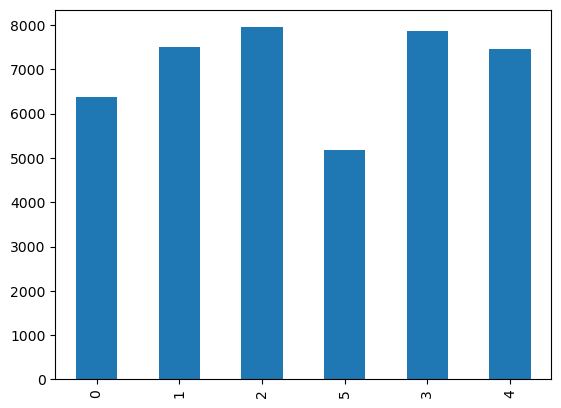

```python
df.cyberbullying_type.value_counts()[df.cyberbullying_type.unique()].plot(kind='bar')
```

## 1.18 Word Cloud

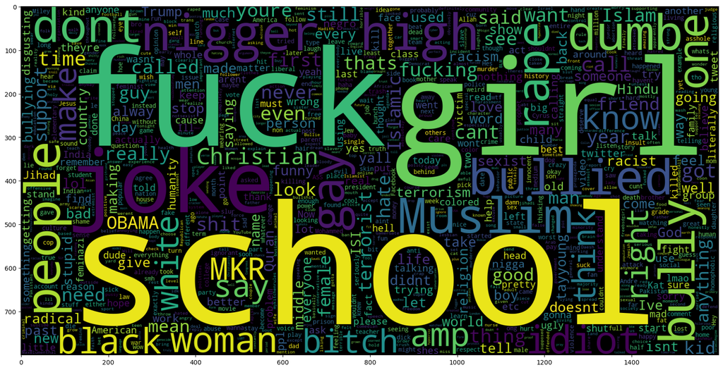

```python
from wordcloud import WordCloud
plt.figure(figsize= (20,20))
wc = WordCloud(max_words=1000, width= 1600, height= 800,
                collocations= False).generate(' '.join(df['tweet_text']))
plt.imshow(wc)
```

## 1.19 Splitting Train Test

```python
df['t_textFinal'] = df['tweet_text']
```

```python
from sklearn.model_selection import train_test_split
from sklearn.metrics import accuracy_score
from sklearn.linear_model import LogisticRegression

t_text = df['t_textFinal']
c_type = df['cyberbullying_type']

X_train, X_test, y_train, y_test = train_test_split(t_text, c_type, test_size=0.2, random_state=42)
```

## 1.20 TFIDF

```python
from sklearn.feature_extraction.text import TfidfVectorizer
# Initialize the TfidfVectorizer
vectorizer = TfidfVectorizer()

# Fit the vectorizer on the training data and transform the training data into a TF-IDF representation
X_train_tfidf = vectorizer.fit_transform(X_train)

# Transform the test data into a TF-IDF representation
X_test_tfidf = vectorizer.transform(X_test)
```

[output not shown]

## 1.21 SMOTE (Oversampling)

```python
from imblearn.over_sampling import SMOTE
vc = y_train.value_counts()
while (vc[0] != vc[4]) or (vc[0] !=  vc[2]) or (vc[0] !=  vc[3]) or (vc[0] !=  vc[1]):
    smote = SMOTE(sampling_strategy='minority')
    X_train_tfidf, y_train = smote.fit_resample(X_train_tfidf, y_train)
    vc = y_train.value_counts()

y_train.value_counts()
```

```
2    6408
0    6408
1    6408
3    6408
5    6408
4    6408
Name: cyberbullying_type, dtype: int64
```

# 2.0 Modelling

#### To measure the performance of each algorithm, the test accuracy will be used as well as the difference between the test and train accuracy to determine the presence of overfitting

[output not shown]

## 2.1 Logistic Regression

### 2.1.1 Train Dataset Results

```python
# # Initialize and train a classifier (e.g., Logistic Regression) using the TF-IDF representation
# logReg = LogisticRegression(max_iter=1000)
# logReg.fit(X_train_tfidf, y_train)

# # Evaluate the performance of the classifier
# accuracy = logReg.score(X_train_tfidf, y_train)
# print("Accuracy:", accuracy)
```

### 2.1.2 Test Data Results

```python
# # Predict on the test data
# y_pred = logReg.predict(X_test_tfidf)

# # Evaluate the performance of the classifier
# accuracy = logReg.score(X_test_tfidf, y_test)
# print("Accuracy:", accuracy)
```

## 2.2 SVM

### Train Data Results

```python
from sklearn.svm import SVC
svm_model_linear = SVC(kernel= 'linear', C = 1, probability = True)
svm_model_linear.fit(X_train_tfidf, y_train)
accuracy = svm_model_linear.score(X_train_tfidf, y_train)
print("Accuracy:", accuracy)
```

```
Accuracy: 0.9637172284644194
```

### Test Data Results

```python
# svm_predictions  = svm_model_linear.predict(X_test_tfidf)
accuracy = svm_model_linear.score(X_test_tfidf, y_test)
print("Accuracy:", accuracy)
```

```
Accuracy: 0.8579525327665604
```

## 2.3 Random Forest Classifier

### 2.3.1 Train Data Results

```python
# from sklearn.ensemble import RandomForestClassifier
# rf = RandomForestClassifier(n_estimators = 30)
# rf.fit(X_train_tfidf, y_train)

# accuracy = rf.score(X_train_tfidf, y_train)
# print("Training Accuracy:", accuracy)
```

### 2.3.2 Test Data Results

```python
# accuracy = rf.score(X_test_tfidf, y_test)
# print("Test Accuracy:", accuracy)
```

## 2.4 Naive Bayes

```python
# from sklearn.naive_bayes import MultinomialNB
# nb = MultinomialNB()
# nb.fit(X_train_tfidf, y_train)
# accuracy = nb.score(X_train_tfidf, y_train)
# print("Training Accuracy:", accuracy)
```

```python
# accuracy = nb.score(X_test_tfidf, y_test)
# print("Training Accuracy:", accuracy)
```

# 3.0 Cross Validation Results

```python
from sklearn.model_selection import cross_val_score
# SVM_cvScore = cross_val_score(svm_model_linear, X_train_tfidf, y_train, cv=5)
SVM_cvScore = cross_val_score(svm_model_linear, X_train_tfidf, y_train, cv=5)
```

```python
print(SVM_cvScore.mean())
```

```
0.8842604392710711
```

# Challenges

#### One of the main challenges in the dataset is the number of duplicated data and the balance between the data categories. Because there are quite a lot of duplicated data, I had to remove them which caused the bullying categories to be unbalanced. Which is why SMOTE was used to solve it, which oversamples the data with synthetic ones to ensure that the categories are balanced.

# Future Work

#### Since the dataset only includes examples of bullying related to ethnicity, and it lacks comments or data that discuss ethnicity without being considered bullying, it makes it challenging for the model to understand what is and isn't related to ethnicity bullying. To improve model performance, the dataset should include data that represents non-bullying discussions about ethnicity.

#### For example in my model, if a user enters "I think black people are good", the model will detect it as bullying, which is obviously wrong

# 4.0 Deployment

## 4.1 Model Testing

## 4.2 Model Deployment Website

```python
import joblib
```

```python
filename = 'cyberbullying_SVM_model.sav'
joblib.dump(svm_model_linear, filename)
```

[output not shown]

```python
tfidf_train_model = vectorizer.fit(X_train)
filename_tfidf = 'tfidf_fit.sav'
joblib.dump(tfidf_train_model, filename_tfidf)
```

[output not shown]

```python
# loading the saved model
loaded_model = joblib.load(open('/Users/nichdylan/Documents/Natural Language Processing/Hezron/cyberbullying_SVM_model.sav', 'rb')) #rb means read as binary
vectorizer = joblib.load(open('/Users/nichdylan/Documents/Natural Language Processing/Hezron/tfidf_fit.sav', 'rb'))
```

[output not shown]

```python
text = ""
text_f = finalClean_text(text)
text_f = vectorizer.transform([text])

prediction = loaded_model.predict(text_f)
prob = loaded_model.predict_proba(text_f)

prob_nonBully = round((prob[0][0])*100)
prob_gender = round((prob[0][1])*100)
prob_religion = round((prob[0][2])*100)
prob_age = round((prob[0][3])*100)
prob_ethnicity = round((prob[0][4])*100)
prob_otherBully = round((prob[0][5])*100)

if prediction[0] == 0 :
    print("This is most likely not cyberbullying with", prob_nonBully, "%")

elif prediction[0] == 1:
    print("This is most likely gender bullying with", prob_gender, "%")

elif prediction[0] == 2:
    print("This is most likely religion bullying with", prob_religion, "%")

elif prediction[0] == 3:
    print("This is most likely age bullying with", prob_age, "%")

elif prediction[0] == 4:
    print("This is most likely ethinicity bullying with", prob_ethnicity, "%")

elif prediction[0] == 5:
    print("This is most likely other cyberbullying with", prob_otherBully, "%")
```

```
This is most likely gender bullying with 85 %
```